# Projet de ML - Supervisé et Non supervisé - L’ensemble de fonctions utilisées sont expliquées dans le document word

### Explotation des datasets

Comme mentioné dans l’intitulé de ce document les fonctions utilisées sont expliquées dans le document word. Ici une base des données unifiée est crée afin de pouvoir réaliser une prèmiere analyse exploratoire sur l’enseble des données du datasets. Il est à noter que cette analyse exploratoire est fait sur le périmètre des actifs (salarie)

```r
source("functions/class_curacion.R")
# lista_data = leyendoData()
# lista_data = workDescUnifier(lista_data)
# lista_data = geographicUnifier(lista_data)
# learn_work = matcheandoData(lista_data,
#                             patron = "learn",
#                             working_status = "Working")
#
# write.csv("datasets/learn_job_pred.csv", row.names=F)
learn_work = read.csv("datasets/learn_job_pred.csv", stringsAsFactors = TRUE, encoding = "UTF-8")

learn_work$X = NULL
learn_work$Y = NULL
print(str(learn_work))
```

```
## 'data.frame':    39397 obs. of  31 variables:
##  $ UID               : int  1 10 8 15 17 18 21 25 31 30 ...
##  $ ECONOMIC_ACTIVITY : Factor w/ 37 levels "AZ","BZ","CA",..: 20 5 17 21 32 20 36 9 20 20 ...
##  $ JOB_DEP           : Factor w/ 96 levels "01","02","03",..: 1 1 1 1 1 1 1 70 1 72 ...
##  $ Terms_of_emp      : Factor w/ 6 levels "APP","AUT","CDD",..: 4 4 4 4 4 4 5 4 4 4 ...
##  $ Job_category      : Factor w/ 3 levels "A","O","X": 2 2 2 2 2 2 2 2 2 2 ...
##  $ JOB_CONDITION     : Factor w/ 6 levels "C","D","F","K",..: 5 1 1 6 5 5 6 1 5 1 ...
##  $ Employer_category : Factor w/ 9 levels "ct_1","ct_2",..: 9 9 9 9 8 9 8 9 5 4 ...
##  $ WORKING_HOURS     : int  843 825 1977 385 1062 1784 1050 2028 697 1854 ...
##  $ employee_count    : Factor w/ 7 levels "tr_0","tr_1",..: 7 1 3 4 2 5 4 4 6 4 ...
##  $ EMOLUMENT         : int  6914 11779 25918 2897 14223 16329 8884 18087 9086 27688 ...
##  $ EMP               : Factor w/ 6 levels "CE-1-1","CE-1-2",..: 6 6 6 6 6 6 5 6 6 6 ...
##  $ Sports            : Factor w/ 2 levels "NO_SPORT","SPORT": 1 1 2 1 2 1 1 1 1 1 ...
##  $ F_name            : Factor w/ 1940 levels "ABD-EL","ABDALLAH",..: 631 1340 1514 1851 376 335 155 1035 400 1800 ...
##  $ LASTNAME          : Factor w/ 31214 levels "AARAB","AARON",..: 15952 15353 140 5471 20295 18115 24820 18453 23616 22699 ...
```

[output cut: 18 more lines]

### Recherche des NA, imputation des NA avec mice et élimination des outlayer

```r
buscandoNAS(list(learn_work))
```

```
##  /\     /\
## {  `---'  }
## {  O   O  }
## ==>  V <==  No need for mice. This data set is completely observed.
##  \  \|/  /
##   `-----'
```

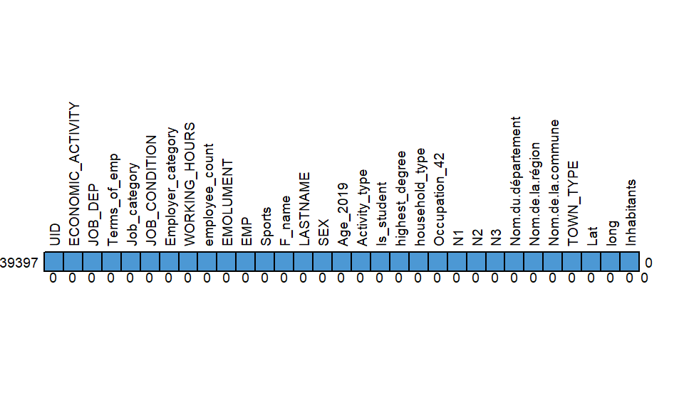

```
## [[1]]
##       UID ECONOMIC_ACTIVITY JOB_DEP Terms_of_emp Job_category JOB_CONDITION
## 39397   1                 1       1            1            1             1
##         0                 0       0            0            0             0
##       Employer_category WORKING_HOURS employee_count EMOLUMENT EMP Sports
## 39397                 1             1              1         1   1      1
##                       0             0              0         0   0      0
##       F_name LASTNAME SEX Age_2019 Activity_type Is_student highest_degree
## 39397      1        1   1        1             1          1              1
##            0        0   0        0             0          0              0
##       household_type Occupation_42 N1 N2 N3 Nom.du.département Nom.de.la.région
## 39397              1             1  1  1  1                  1                1
##                    0             0  0  0  0                  0                0
##       Nom.de.la.commune TOWN_TYPE Lat long Inhabitants
## 39397                 1         1   1    1           1 0
##                       0         0   0    0           0 0
```

```r
learn_work = imputeSportsWorkingHoursOutlierHandling(learn_work)
str(learn_work)
```

```
## 'data.frame':    39397 obs. of  31 variables:
##  $ UID               : int  1 10 8 15 17 18 21 25 31 30 ...
##  $ ECONOMIC_ACTIVITY : Factor w/ 37 levels "AZ","BZ","CA",..: 20 5 17 21 32 20 36 9 20 20 ...
##  $ JOB_DEP           : Factor w/ 96 levels "01","02","03",..: 1 1 1 1 1 1 1 70 1 72 ...
##  $ Terms_of_emp      : Factor w/ 6 levels "APP","AUT","CDD",..: 4 4 4 4 4 4 5 4 4 4 ...
##  $ Job_category      : Factor w/ 3 levels "A","O","X": 2 2 2 2 2 2 2 2 2 2 ...
##  $ JOB_CONDITION     : Factor w/ 6 levels "C","D","F","K",..: 5 1 1 6 5 5 6 1 5 1 ...
##  $ Employer_category : Factor w/ 9 levels "ct_1","ct_2",..: 9 9 9 9 8 9 8 9 5 4 ...
##  $ WORKING_HOURS     : int  843 825 1977 385 1062 1784 1050 2028 697 1854 ...
##  $ employee_count    : Factor w/ 7 levels "tr_0","tr_1",..: 7 1 3 4 2 5 4 4 6 4 ...
##  $ EMOLUMENT         : int  6914 11779 25918 2897 14223 16329 8884 18087 9086 27688 ...
##  $ EMP               : Factor w/ 6 levels "CE-1-1","CE-1-2",..: 6 6 6 6 6 6 5 6 6 6 ...
##  $ Sports            : Factor w/ 2 levels "NO_SPORT","SPORT": 1 1 2 1 2 1 1 1 1 1 ...
##  $ F_name            : Factor w/ 1940 levels "ABD-EL","ABDALLAH",..: 631 1340 1514 1851 376 335 155 1035 400 1800 ...
##  $ LASTNAME          : Factor w/ 31214 levels "AARAB","AARON",..: 15952 15353 140 5471 20295 18115 24820 18453 23616 22699 ...
```

[output cut: 17 more lines]

### Analyse exploratoire (voir documents: “1_Data Analyse en fonction de salaire” et “2_Data analyse par variable”)

Cette partie permet de mieux comprendre les données. Qaund le nombre des modalités est trés élevé l’analyse est très complex (exp, le département de travail), pour ça une analyse des en fonction de départements a été fait dans la partie Non supervisé.

1_Data Analyse en fonction de salaire, chaque varaible est representée en focntion de l’emolument qui est la variable à prédire :

-Le secteur publique bénéfice des salaires plus intéressants que des autres catégories. -Les grands entreprise ( + 250 salariés)rémunèrent en moyenne mieux ces collaborateurs -Les salariés qui travaillent à temps plein gagnent mieux sa vie que le temps partiel ou à domiciles -Sexe, il est constaté que globalment (hormis de niche espécifique) les hommes ont un salaire supérieur que les fammes (la médianne est plus importante chez les hommes). Aussi il est constaté un salaire outlayer pour les fammes à 200K€.

2_Data analyse par variable, chaque variable est répresenté toute suele afin de mieux comprend ça distribution:

-la variable à prédire a une repartition proche de la distribution poisson/binomiale négative -les variables (terms_emp, job category, job condition», employer_categorie, household, Emp) ont une modalité que regroupe l’ensemble des observations -la représentation des étudiants est faible dans la basse de learn -le représentation de femmes et homes est équivalente dans la base d’apprentissage. La data est équilibrée

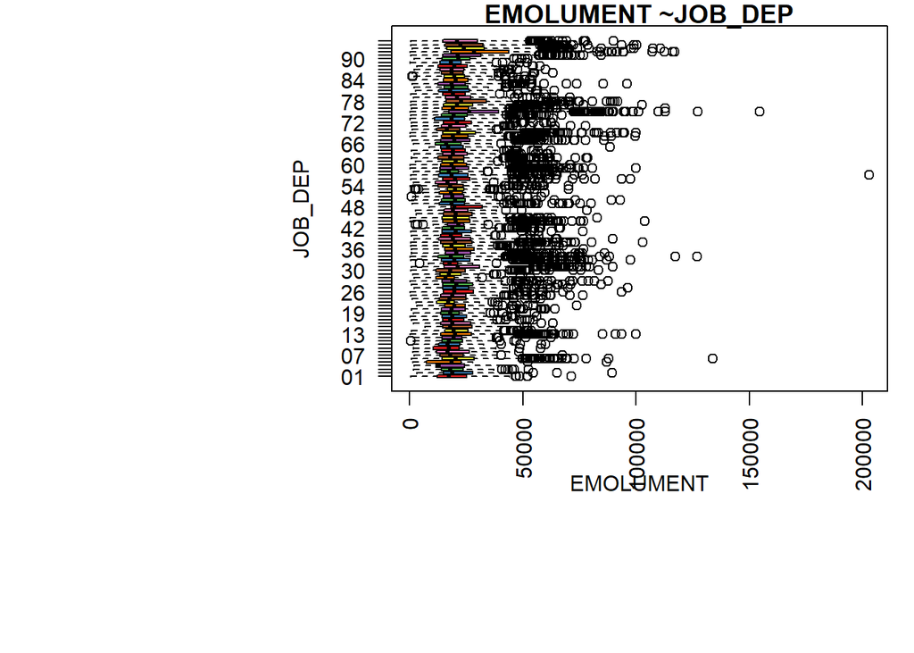

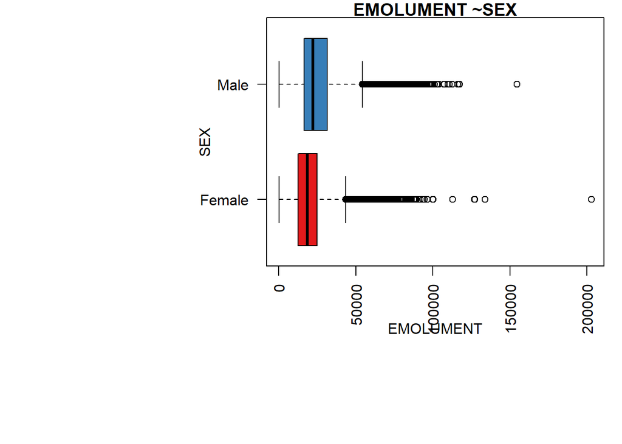

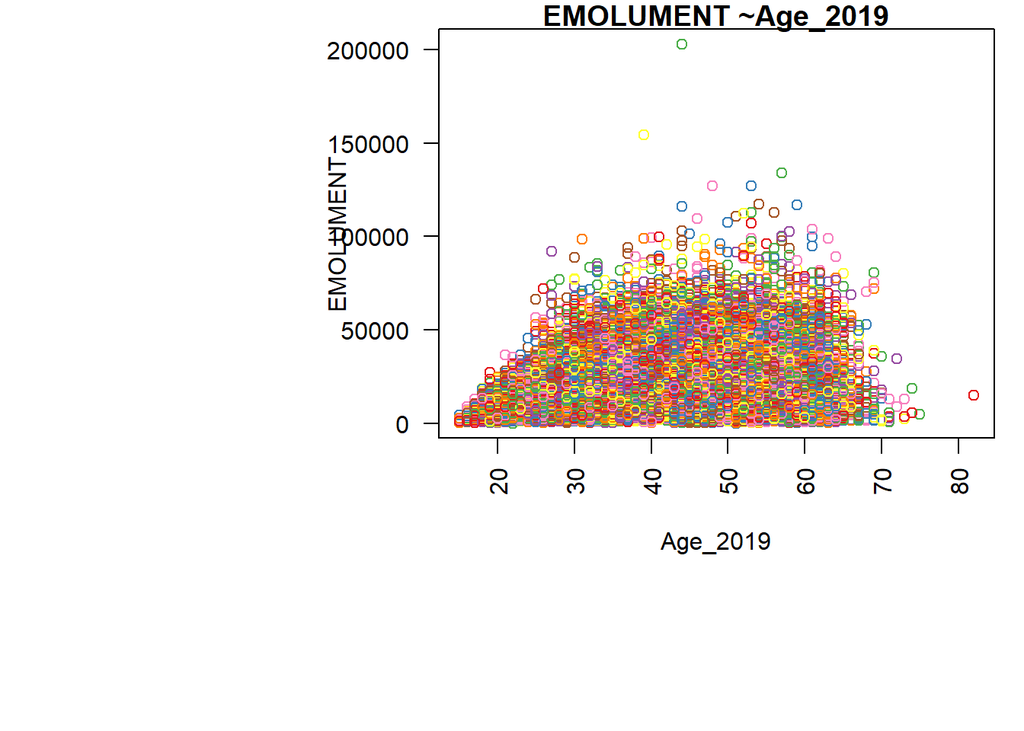

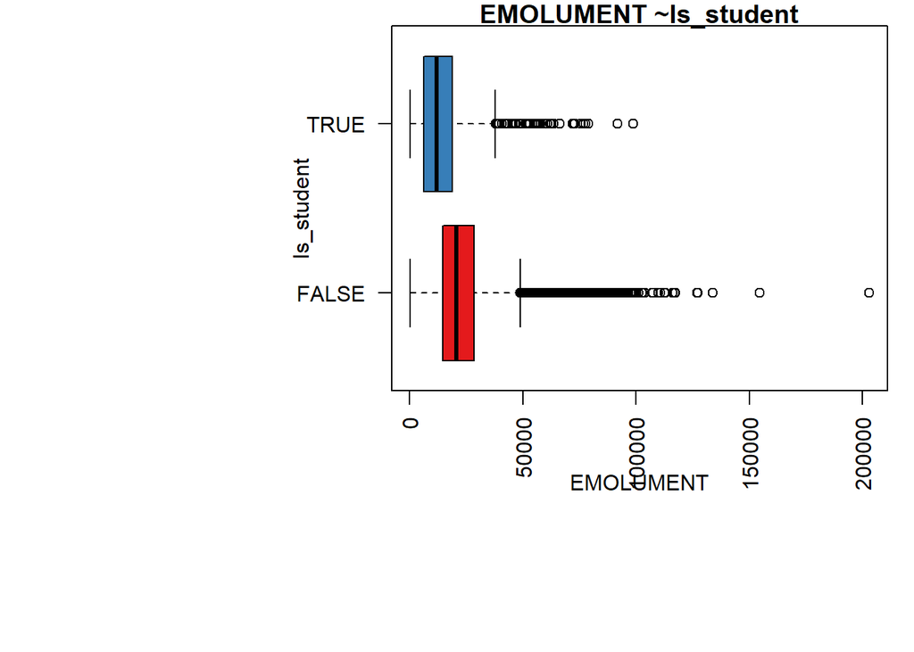

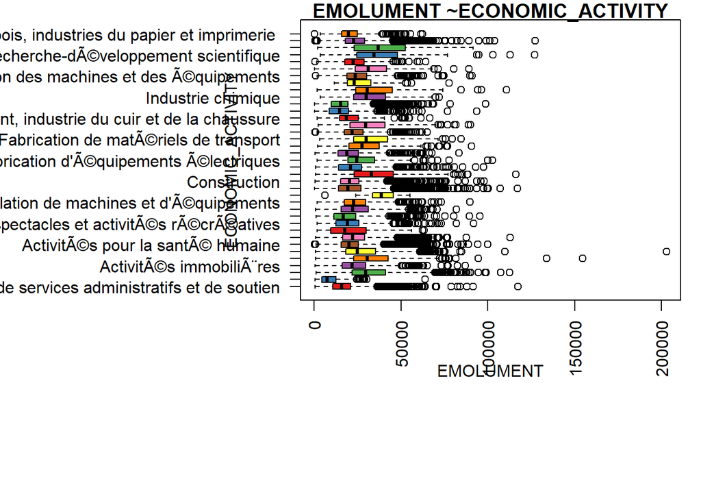

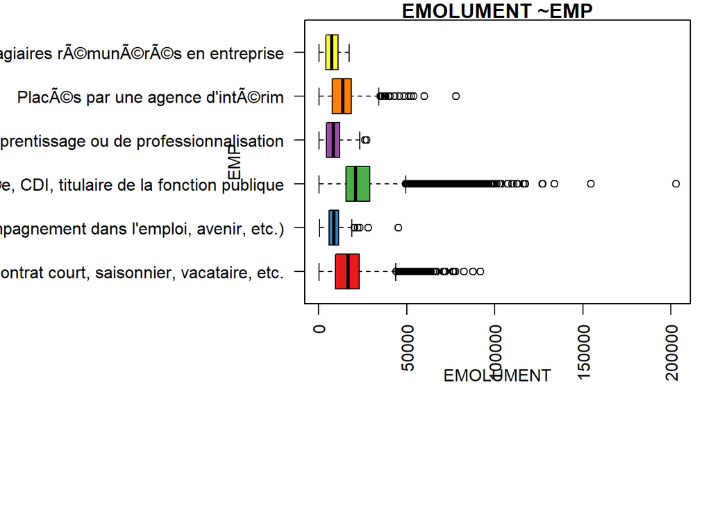

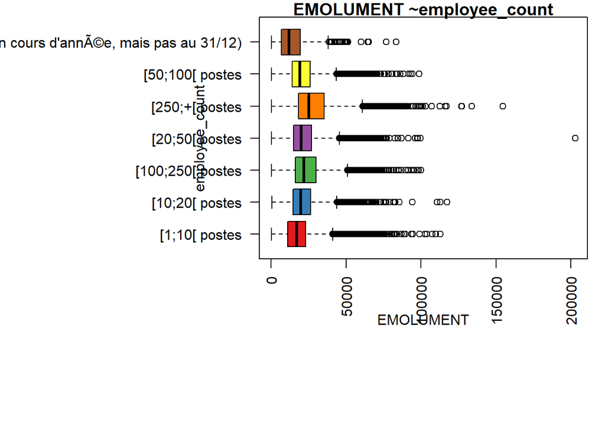

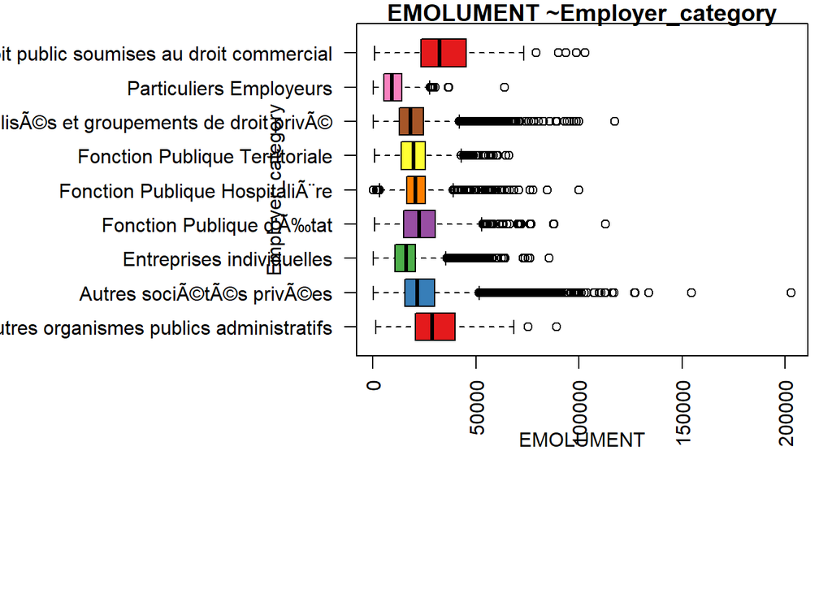

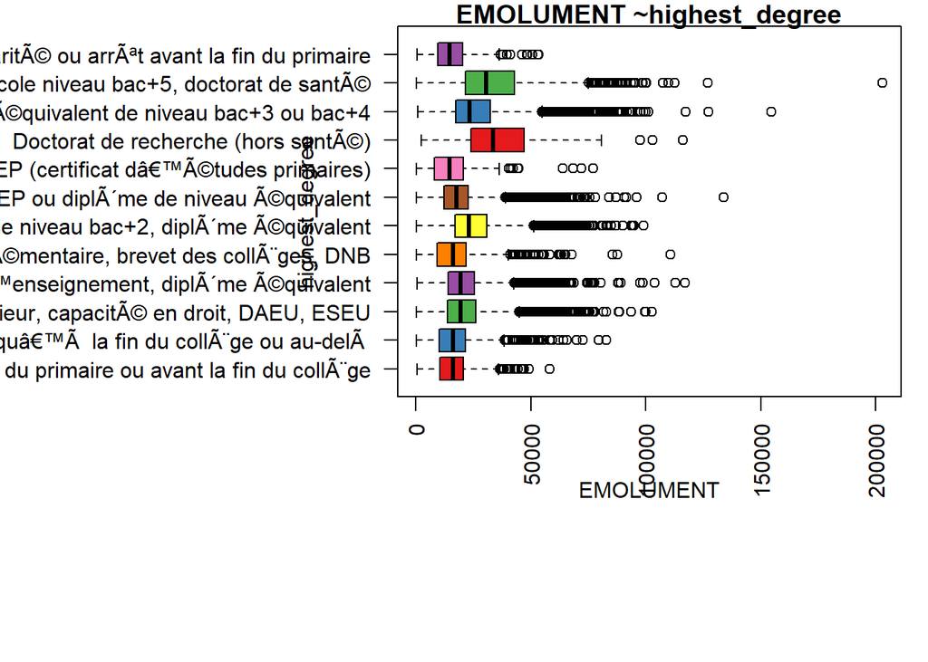

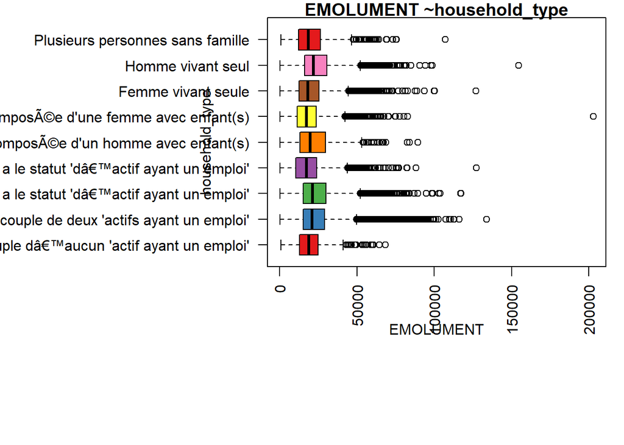

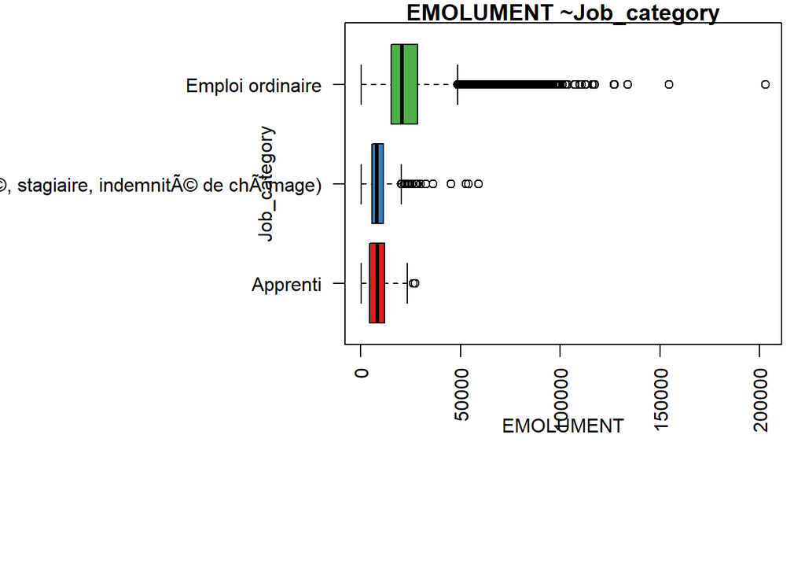

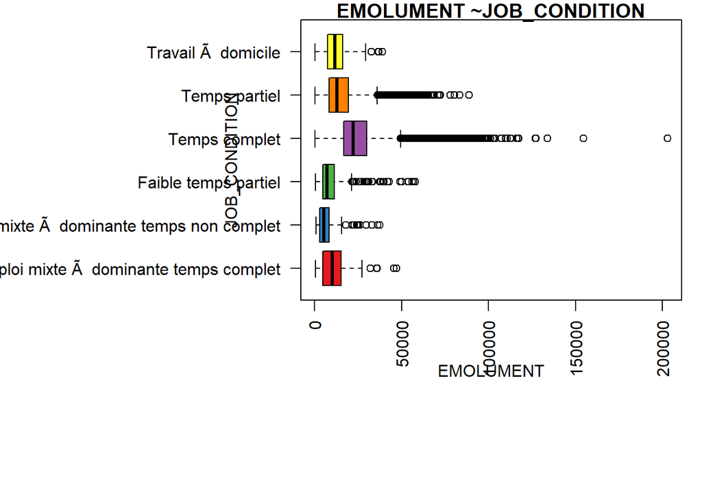

[13 more figures not shown]

```r
learn_work_desc = read.csv("datasets/learn_job_desc.csv")
learn_work_desc = learn_work_desc[, -grep(colnames(learn_work_desc), pattern ="Activity_type|Nom.de.la.commune|UID|F_name|LASTNAME")]
descriptivePlotsDbJob(learn_work_desc)
```

### Graphique des coefficients R2 en fonction de la variable à prédire (Emolument)

Ce R2 pourrais s’approché à un coefficient de corrélation entre la variable à prédire (émolument) et la variable affiché dans le graphique ci-après. Cette analyse a servi à identifier les variables du modèle, elles seront utilisées pour la modèlisation. Le variables avec des informations trés corréllés ont été écarté du modèle.

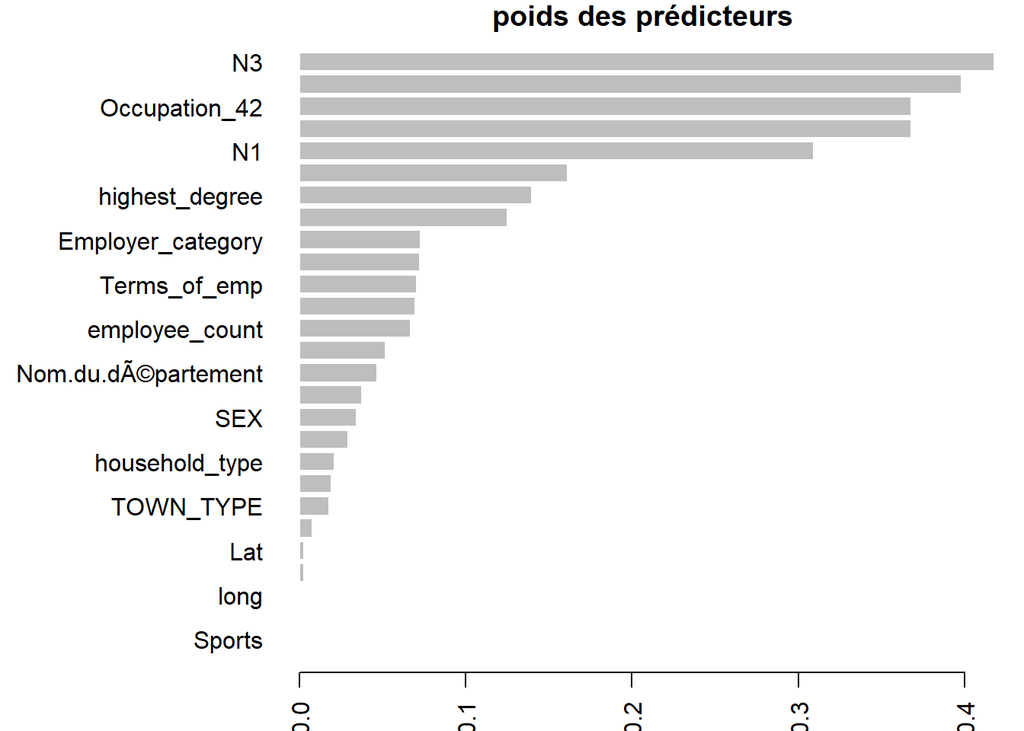

```r
# r2 = emolumentVSall(learn_work)# 1 - deviance/null.deviance
pesos = read.csv("datasets/pesos_predictores.csv")
par(mar=c(2,10,1,1))
barplot(pesos[,3],
        names.arg = pesos[,2],
        horiz =T,
        border="white",
        las =2,
        main = "poids des prédicteurs")
```

### Preprocessing data

```r
# écarter les variables "Activity_type|Nom.de.la.commune|UID|F_name|LASTNAME"
db = learn_work[, -grep(colnames(learn_work), pattern ="Activity_type|Nom.de.la.commune|UID|F_name|LASTNAME")]
# dataset train et test
train = dataSubSampler(db, train = T, seed = 3141)
test = dataSubSampler(db, train = F, seed = 3141)
```

### Modèle linéaire

Le R^2 de ce modèle est de 69,5% avec un RMSE de 7455,9 et un AIC de 652278,5

```r
mod_lineal = lm(data = train, EMOLUMENT ~ N3 + WORKING_HOURS + Occupation_42 +
                                ECONOMIC_ACTIVITY + highest_degree + JOB_CONDITION + EMP + Sports)
save(mod_lineal, file = "models/mod_lineal.RData")
load("models/mod_lineal.RData")
# predictions
pred_reg_lin = predict(mod_lineal, test)
yhat = pred_reg_lin
y = test$EMOLUMENT
RMSE0 = sqrt(sum((yhat-y)^2)/nrow(test))
r2_0 = 1-(RMSE0^2/var(y))
aic_0 = AIC(mod_lineal)
df0 = data.frame("MODELO" = "lm", "r2_0" = r2_0, "RMSE" = RMSE0, "AIC" = aic_0)
print(df0)
```

```
##   MODELO      r2_0     RMSE      AIC
## 1     lm 0.6950855 7455.974 652278.5
```

### Modèle linéaire généralisé (regression binomial negative)

L’analyse exploratoire permet de penser à une distribution de poisson pour la variable à prédire “émolument”. En revanche, l’écart entre la moyenne et la variance incline la décision de la distribution sur une  
binôme négative.

Le R^2 de ce modèle est de 69,5% avec un RMSE de 7449,8 et un AIC de 639910,7

```r
mod_bin_neg = MASS::glm.nb(data = train,
                    EMOLUMENT ~ N3 + WORKING_HOURS + Occupation_42 +
                    ECONOMIC_ACTIVITY + highest_degree + JOB_CONDITION+EMP+Sports)
save(mod_bin_neg, file = "models/mod_bin_neg.RData")
load("models/mod_bin_neg.RData")
# prédictions
pred_bin_neg = predict(mod_bin_neg, test)
yhat = exp(pred_bin_neg)
y = test$EMOLUMENT
RMSE1 = sqrt(sum((yhat-y)^2)/nrow(test))
r2_1 = 1-(RMSE1^2/var(y))
aic_1 = AIC(mod_bin_neg)
df1 = data.frame("MODELO" = "neg_bin_lm", "r2_0" = r2_1, "RMSE" = RMSE1, "AIC" = aic_1)
print(df1)
```

```
##       MODELO      r2_0     RMSE      AIC
## 1 neg_bin_lm 0.6955898 7449.806 639910.7
```

### XGBoost - Avec l’ensemble des variables

XGBoost (Extreme Gradient Boosting) est un algorithme prédictif qui combine le pouvoir des arbres de décision/régression avec l’algorithme de descente de gradient stochastique. Cela permet d’explorer l’espace des solutions optimales pour estimer la variable EMOLUMENT.

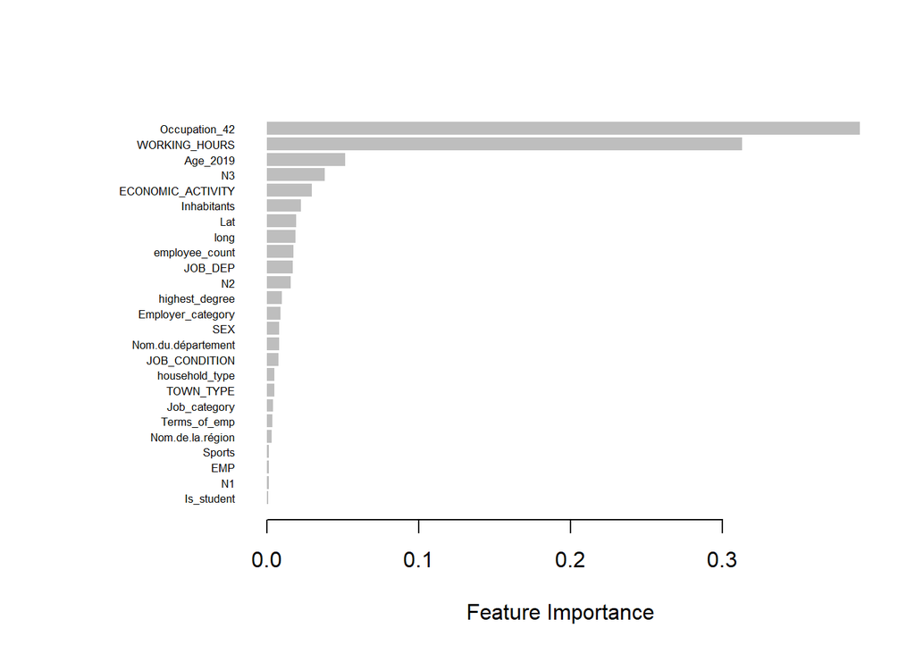

```r
# mod_xgboost = mod_XGboost(train)
load("models/mod_xgboost_sinXY.RData")
importance_matrix = xgboost::xgb.importance(model = mod_xgboost)
xgboost::xgb.plot.importance(importance_matrix, xlab = "Feature Importance")
```

```r
# Prédictions

test_num = as.data.frame(lapply(test, function (x)as.numeric(x)))
test_num
```

[output not shown]

```r
pred_xgb = predict(mod_xgboost, as.matrix(test_num[,-9]))
yhat = pred_xgb
y = test_num$EMOLUMENT
RMSE2 = sqrt(sum((yhat-y)^2)/nrow(test_num))
r2_2 = 1-(RMSE2^2/var(y))
df2 = data.frame("MODELO" = "xgboost", "r2_0" = r2_2, "RMSE" = RMSE2, "AIC" = NA)
print(df2)
```

```
##    MODELO     r2_0     RMSE AIC
## 1 xgboost 0.752731 6714.292  NA
```

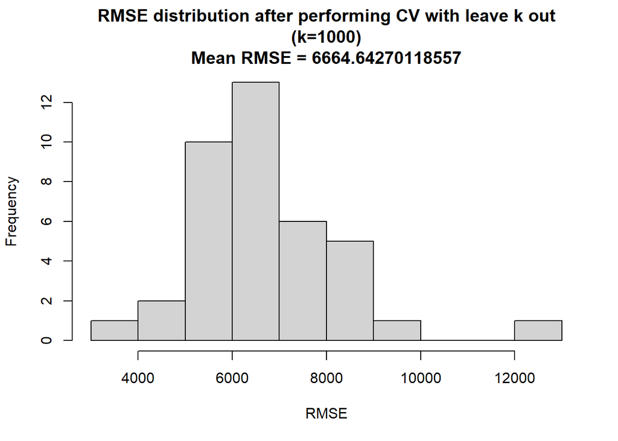

```r
### Performing CV
set.seed(1234)
db_permutated = db[sample(1:nrow(db), size = nrow(db), replace = FALSE),]
leave_k_out = function(db, k){
        m = nrow(db)/k
        lista_RMSE2 = list()
        for(i in 1:m) {
                print(i)
                if(i == m) m = nrow(db)%%k
                test_k  = db[k*(i-1)+1:m,]
                train_k = db[-(k*(i-1)+1:m),]
                # repeat adjusting process.
                mod_xgboost = mod_XGboost(train_k, save = FALSE)
                test_num = as.data.frame(lapply(test_k,as.numeric))
                pred_xgb = tryCatch(predict(mod_xgboost, as.matrix(test_num[,-9])), error = function(e) NULL)
                if(is.null(pred_xgb)) next
                yhat = pred_xgb
                y = test_num$EMOLUMENT
                RMSE2 = sqrt(sum((yhat-y)^2)/nrow(test_num))
                lista_RMSE2[[i]] = RMSE2
                print(RMSE2)
        }
        return(lista_RMSE2)
}
### Performing CV leaving K out, with K = 1000
# CV_RMSE2 = leave_k_out(db_permutated, 1000)
# save(CV_RMSE2, file = "datasets/CV_RMSE2.RData")
load("datasets/CV_RMSE2.RData")
hist(unlist(CV_RMSE2),
            main = paste0("RMSE distribution after performing CV with leave k out\n(k=1000)\nMean RMSE = ", mean(unlist(CV_RMSE2))),
            xlab = "RMSE")
```

### Coparaison des trois modèles:

Comment évoqué précedament le meilleur modèle est le XGBoost avec un R^2 de 75% et le plus petit RMSE

```r
DF = do.call("rbind", list(df0,df1,df2))
print(DF)
```

```
##       MODELO      r2_0     RMSE      AIC
## 1         lm 0.6950855 7455.974 652278.5
## 2 neg_bin_lm 0.6955898 7449.806 639910.7
## 3    xgboost 0.7527310 6714.292       NA
```

Loading test data and building predictions. Controlling for assigning the same levels in this test as the ones used with the learning dataset.

```r
# Loading Test data
# lista_data = leyendoData()
# lista_data = workDescUnifier(lista_data)
# lista_data = geographicUnifier(lista_data)
# TEST = matcheandoData(lista_data,
#                       patron = "test"
#                      )
# TEST0 = matcheandoCode(TEST, lista_data, patron = "Work_desc|Insee")
# TEST0$X = NULL
# TEST0$Y = NULL
# # Fixing inconsenstincies between factors from train and test
# patron_cols = paste0(setdiff(colnames(TEST0),colnames(train)), collapse = "|")
# ind_cols = grep(pattern = patron_cols, colnames(TEST0))
# TEST0_id = TEST0[,ind_cols]
# write.csv(TEST0_id, "datasets/test_ids.csv", row.names=FALSE)

##test_id = read.csv("datasets/test_ids.csv")

# TEST0_forecast = TEST0[,-ind_cols]
# lista_levels = lapply(train,levels)
# TEST1_forecast = TEST0_forecast
# for(i in 1:ncol(TEST0_forecast)){
#         if(class(TEST0_forecast[,i]) == "factor"){
#                 ind = grep(colnames(train), pattern = colnames(TEST0_forecast)[i])
#                 TEST1_forecast[,i]= factor(TEST0_forecast[,i], levels = lista_levels[[ind]])
#         }
# }
# write.csv(TEST1_forecast, "datasets/test_forecast.csv", row.names = FALSE)

# test_forecast = read.csv("datasets/test_forecast.csv")
# test_forecast_num = as.matrix(as.data.frame(lapply(test_forecast,as.numeric)))
# test_forecast_num_ord =  test_forecast_num[,mod_xgboost$feature_names]
# predictions = predict(mod_xgboost, test_forecast_num_ord)
# test_predictions = cbind("UID"=test_id$UID,predictions)
# write.csv(test_predictions, "datasets/test_with_predictions.csv", row.names=FALSE)
```